# Part I - (Dataset Exploration of Fordgobike Share Trip in San Francisco)

## by (Ismaila Abdullahi Adavize)

## Introduction

> This data set includes information about individual rides made in a bike-sharing system covering the greater San Francisco Bay area.

## Preliminary Wrangling

```python
# import all packages and set plots to be embedded inline
import numpy as np
import pandas as pd
import matplotlib.pyplot as plt
import seaborn as sb

%matplotlib inline
```

> Load in your dataset and describe its properties through the questions below. Try and motivate your exploration goals through this section.

```python
#loading the dataset into a dataframe named fordgobike
fordgobike = pd.read_csv('201902-fordgobike-tripdata.csv')
```

```python
fordgobike.head()
```

|  | duration_sec | start_time | end_time | start_station_id | start_station_name | start_station_latitude | start_station_longitude | end_station_id | end_station_name | end_station_latitude | end_station_longitude | bike_id | user_type | member_birth_year | member_gender | bike_share_for_all_trip |
| --- | --- | --- | --- | --- | --- | --- | --- | --- | --- | --- | --- | --- | --- | --- | --- | --- |
| 0 | 52185 | 2019-02-28 17:32:10.1450 | 2019-03-01 08:01:55.9750 | 21.0 | Montgomery St BART Station (Market St at 2nd St) | 37.789625 | -122.400811 | 13.0 | Commercial St at Montgomery St | 37.794231 | -122.402923 | 4902 | Customer | 1984.0 | Male | No |
| 1 | 42521 | 2019-02-28 18:53:21.7890 | 2019-03-01 06:42:03.0560 | 23.0 | The Embarcadero at Steuart St | 37.791464 | -122.391034 | 81.0 | Berry St at 4th St | 37.775880 | -122.393170 | 2535 | Customer | NaN | NaN | No |
| 2 | 61854 | 2019-02-28 12:13:13.2180 | 2019-03-01 05:24:08.1460 | 86.0 | Market St at Dolores St | 37.769305 | -122.426826 | 3.0 | Powell St BART Station (Market St at 4th St) | 37.786375 | -122.404904 | 5905 | Customer | 1972.0 | Male | No |
| 3 | 36490 | 2019-02-28 17:54:26.0100 | 2019-03-01 04:02:36.8420 | 375.0 | Grove St at Masonic Ave | 37.774836 | -122.446546 | 70.0 | Central Ave at Fell St | 37.773311 | -122.444293 | 6638 | Subscriber | 1989.0 | Other | No |
| 4 | 1585 | 2019-02-28 23:54:18.5490 | 2019-03-01 00:20:44.0740 | 7.0 | Frank H Ogawa Plaza | 37.804562 | -122.271738 | 222.0 | 10th Ave at E 15th St | 37.792714 | -122.248780 | 4898 | Subscriber | 1974.0 | Male | Yes |

```python
#checking to see the columns in my dataset
fordgobike.columns
```

```
Index(['duration_sec', 'start_time', 'end_time', 'start_station_id',
       'start_station_name', 'start_station_latitude',
       'start_station_longitude', 'end_station_id', 'end_station_name',
       'end_station_latitude', 'end_station_longitude', 'bike_id', 'user_type',
       'member_birth_year', 'member_gender', 'bike_share_for_all_trip'],
      dtype='object')
```

```python
#checking the the datase programmatically to enquire more information about my dataset (missing value, data types, and shape(dimention of the dataset) )
print(fordgobike.isnull().sum())
print(fordgobike.dtypes)
print(fordgobike.shape)
```

```
duration_sec                  0
start_time                    0
end_time                      0
start_station_id            197
start_station_name          197
start_station_latitude        0
start_station_longitude       0
end_station_id              197
end_station_name            197
end_station_latitude          0
end_station_longitude         0
bike_id                       0
user_type                     0
member_birth_year          8265
member_gender              8265
bike_share_for_all_trip       0
dtype: int64
duration_sec                 int64
start_time                  object
end_time                    object
start_station_id           float64
start_station_name          object
start_station_latitude     float64
start_station_longitude    float64
end_station_id             float64
end_station_name            object
end_station_latitude       float64
end_station_longitude      float64
bike_id                      int64
user_type                   object
member_birth_year          float64
member_gender               object
bike_share_for_all_trip     object
dtype: object
(183412, 16)
```

```python
#checking the dataset set user type counts
fordgobike.user_type.value_counts()
```

```
Subscriber    163544
Customer       19868
Name: user_type, dtype: int64
```

## Dataset Wrangling:

#### To start visualization, let's clean the dataset for clearer analysis and visualization of data.(using the Define, code and test framework approach)

```python
#making a copy of my data set and laoding into df_fordgobike
df_fordgobike = fordgobike.copy()
```

### Code:

```python
#using the isna() funtion to drop all the missing values in my data set
df_fordgobike = df_fordgobike.dropna()
```

### Test:

```python
#checking the data set if is free of missing values
df_fordgobike.isna().sum()
```

```
duration_sec               0
start_time                 0
end_time                   0
start_station_id           0
start_station_name         0
start_station_latitude     0
start_station_longitude    0
end_station_id             0
end_station_name           0
end_station_latitude       0
end_station_longitude      0
bike_id                    0
user_type                  0
member_birth_year          0
member_gender              0
bike_share_for_all_trip    0
dtype: int64
```

### Define:

#### Converting member_birth_year to Age(years) and to datatype integer.

### Code:

```python
"""converting member_birth_year column to Age to get it in number
"""
df_fordgobike['Age'] = df_fordgobike['member_birth_year'].apply(lambda x: 2019 - x)
```

```python
#after creating an extra column Age, i'm checking
df_fordgobike['Age'].value_counts().sum()
```

```
174952
```

```python
#converting the datatype to integer
df_fordgobike['Age'] = df_fordgobike['Age'].astype('int')
```

```python
#setting the min and max of the age
df_fordgobike= df_fordgobike[(df_fordgobike['Age'] > 15) | (df_fordgobike['Age'] < 80)]
```

## Test

```python
#checking for the value
df_fordgobike['Age'].value_counts()
```

```
31     10214
26      9323
30      8967
29      8640
28      8484
27      8245
32      8010
33      7953
25      7654
24      7420
34      7023
35      6557
36      5953
39      5011
37      4987
```

[output cut: 47 more lines]

### Define:

#### Catigorizing age into Age_group

### Code:

```python
#ctegorizing the gaes in to teenagers, youths,adults,old_adults using list
bin_edges = [15, 19, 30, 45, 80]
bin_names = ['teenagers', 'youths','adults','old_adults']
```

```python
#categorizing the age into age group and settin it into bins
df_fordgobike['age_groups'] = pd.cut(df_fordgobike['Age'], bin_edges, labels=bin_names)
```

### Test:

```python
#checking my dataset for overview
df_fordgobike.head(10)
```

|  | duration_sec | start_time | end_time | start_station_id | start_station_name | start_station_latitude | start_station_longitude | end_station_id | end_station_name | end_station_latitude | end_station_longitude | bike_id | user_type | member_birth_year | member_gender | bike_share_for_all_trip | Age | age_groups |
| --- | --- | --- | --- | --- | --- | --- | --- | --- | --- | --- | --- | --- | --- | --- | --- | --- | --- | --- |
| 0 | 52185 | 2019-02-28 17:32:10.1450 | 2019-03-01 08:01:55.9750 | 21.0 | Montgomery St BART Station (Market St at 2nd St) | 37.789625 | -122.400811 | 13.0 | Commercial St at Montgomery St | 37.794231 | -122.402923 | 4902 | Customer | 1984.0 | Male | No | 35 | adults |
| 2 | 61854 | 2019-02-28 12:13:13.2180 | 2019-03-01 05:24:08.1460 | 86.0 | Market St at Dolores St | 37.769305 | -122.426826 | 3.0 | Powell St BART Station (Market St at 4th St) | 37.786375 | -122.404904 | 5905 | Customer | 1972.0 | Male | No | 47 | old_adults |
| 3 | 36490 | 2019-02-28 17:54:26.0100 | 2019-03-01 04:02:36.8420 | 375.0 | Grove St at Masonic Ave | 37.774836 | -122.446546 | 70.0 | Central Ave at Fell St | 37.773311 | -122.444293 | 6638 | Subscriber | 1989.0 | Other | No | 30 | youths |
| 4 | 1585 | 2019-02-28 23:54:18.5490 | 2019-03-01 00:20:44.0740 | 7.0 | Frank H Ogawa Plaza | 37.804562 | -122.271738 | 222.0 | 10th Ave at E 15th St | 37.792714 | -122.248780 | 4898 | Subscriber | 1974.0 | Male | Yes | 45 | adults |
| 5 | 1793 | 2019-02-28 23:49:58.6320 | 2019-03-01 00:19:51.7600 | 93.0 | 4th St at Mission Bay Blvd S | 37.770407 | -122.391198 | 323.0 | Broadway at Kearny | 37.798014 | -122.405950 | 5200 | Subscriber | 1959.0 | Male | No | 60 | old_adults |
| 6 | 1147 | 2019-02-28 23:55:35.1040 | 2019-03-01 00:14:42.5880 | 300.0 | Palm St at Willow St | 37.317298 | -121.884995 | 312.0 | San Jose Diridon Station | 37.329732 | -121.901782 | 3803 | Subscriber | 1983.0 | Female | No | 36 | adults |
| 7 | 1615 | 2019-02-28 23:41:06.7660 | 2019-03-01 00:08:02.7560 | 10.0 | Washington St at Kearny St | 37.795393 | -122.404770 | 127.0 | Valencia St at 21st St | 37.756708 | -122.421025 | 6329 | Subscriber | 1989.0 | Male | No | 30 | youths |
| 8 | 1570 | 2019-02-28 23:41:48.7900 | 2019-03-01 00:07:59.7150 | 10.0 | Washington St at Kearny St | 37.795393 | -122.404770 | 127.0 | Valencia St at 21st St | 37.756708 | -122.421025 | 6548 | Subscriber | 1988.0 | Other | No | 31 | adults |
| 9 | 1049 | 2019-02-28 23:49:47.6990 | 2019-03-01 00:07:17.0250 | 19.0 | Post St at Kearny St | 37.788975 | -122.403452 | 121.0 | Mission Playground | 37.759210 | -122.421339 | 6488 | Subscriber | 1992.0 | Male | No | 27 | youths |
| 10 | 458 | 2019-02-28 23:57:57.2110 | 2019-03-01 00:05:35.4350 | 370.0 | Jones St at Post St | 37.787327 | -122.413278 | 43.0 | San Francisco Public Library (Grove St at Hyde... | 37.778768 | -122.415929 | 5318 | Subscriber | 1996.0 | Female | Yes | 23 | youths |

```python
#checking the counts of the age group
df_fordgobike['age_groups'].value_counts()
```

```
adults        76915
youths        72558
old_adults    23578
teenagers      1709
Name: age_groups, dtype: int64
```

### Define:

#### converting some columns to Categorical data type

### Code:

```python
#converting user_type,member_gender,bike_share_for_all_trip to categorical data type
for col in ['user_type','member_gender','bike_share_for_all_trip']:
    df_fordgobike[col] = df_fordgobike[col].astype('category')
```

### Test:

```python
#checking for the data types
df_fordgobike.dtypes
```

```
duration_sec                  int64
start_time                   object
end_time                     object
start_station_id            float64
start_station_name           object
start_station_latitude      float64
start_station_longitude     float64
end_station_id              float64
end_station_name             object
end_station_latitude        float64
end_station_longitude       float64
bike_id                       int64
user_type                  category
member_birth_year           float64
member_gender              category
bike_share_for_all_trip    category
Age                           int32
age_groups                 category
dtype: object
```

```python
#saving my cleaned dataset to a new csv file fordgobike_clean.csv
df_fordgobike.to_csv('fordgobike_clean.csv' ,index = False)
```

```python
#loading the new csv file and checking for the dataset
fordgobike_clean = pd.read_csv('fordgobike_clean.csv')
fordgobike_clean.sample()
```

|  | duration_sec | start_time | end_time | start_station_id | start_station_name | start_station_latitude | start_station_longitude | end_station_id | end_station_name | end_station_latitude | end_station_longitude | bike_id | user_type | member_birth_year | member_gender | bike_share_for_all_trip | Age | age_groups |
| --- | --- | --- | --- | --- | --- | --- | --- | --- | --- | --- | --- | --- | --- | --- | --- | --- | --- | --- |
| 105934 | 366 | 2019-02-12 17:31:44.7460 | 2019-02-12 17:37:50.9130 | 50.0 | 2nd St at Townsend St | 37.780526 | -122.390288 | 21.0 | Montgomery St BART Station (Market St at 2nd St) | 37.789625 | -122.400811 | 3429 | Subscriber | 1980.0 | Male | No | 39 | adults |

### What is the structure of your dataset?

> Your answer here! the dataset has 183412 variables and 16 features, the features include (duration_sec, start_time, end_time, start_station_id, start_station_name, start_station_latitude, start_station_longitude, end_station_id, end_station_name, end_station_latitude, end_station_longitude, bike_id, user_type, member_birth_year, member_gender, bike_share_for_all_trip) after my wrangling process there was a total of 174952 rows and 18 columns adding two columns (age and age_group)

### What is/are the main feature(s) of interest in your dataset?

> Your answer here! The main feature of interest in this dataset include duration time in seconds of each bike share trip, Member_birth_year (Age), Member_gender. member_birth_year was converted to Age and structured into Age Groups. I will insight the relationship between these features and other variables in the dataset.

## Univariate Exploration

> In this section, investigate distributions of individual variables. If you see unusual points or outliers, take a deeper look to clean things up and prepare yourself to look at relationships between variables.

> **Rubric Tip**: The project (Parts I alone) should have at least 15 visualizations distributed over univariate, bivariate, and multivariate plots to explore many relationships in the data set. Use reasoning to justify the flow of the exploration.

> **Rubric Tip**: Use the "Question-Visualization-Observations" framework throughout the exploration. This framework involves **asking a question from the data, creating a visualization to find answers, and then recording observations after each visualisation.**

## Visualization:

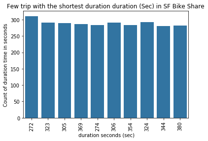

```python
#bar chart to diplay the shortest duration in second
base_color = sb.color_palette()[0]
duration = fordgobike_clean.duration_sec.value_counts()[:10].index
sb.countplot(data = fordgobike, x = 'duration_sec', color = base_color, order = duration)
plt.xticks(rotation = 90)
plt.ylabel('Count of duration time in seconds')
plt.xlabel(' duration seconds (sec)')
plt.title('Few trip with the shortest duration duration (Sec) in SF Bike Share');
```

## Question:

### How does the duration of the trip related to the average trip taken?

## Visualization:

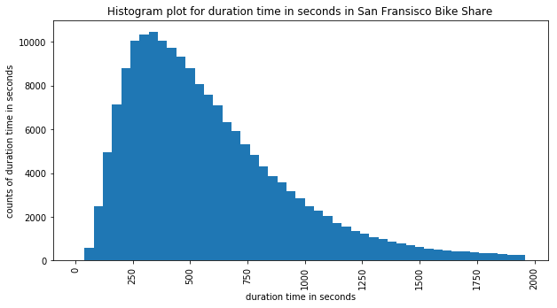

```python
# Plotting a Histogram to show the relationship between duration time and its count
binsize = 40
bins = np.arange(0, 2000, binsize)
plt.figure(figsize=[10, 5])
base_color = sb.color_palette()[0]
plt.hist(data = fordgobike, x = 'duration_sec', color = base_color, bins = bins)
plt.xticks(rotation = 90)
plt.xlabel('duration time in seconds')
plt.ylabel('counts of duration time in seconds')
plt.title('Histogram plot for duration time in seconds in San Fransisco Bike Share');
plt.show()
```

## Observation:

##### I have observed that the counts duration is higher when the duration time is the range of 250 to 550

```python
# checking the start station name counts
fordgobike_clean['start_station_name'].value_counts()[:10]
```

```
Market St at 10th St                                         3649
San Francisco Caltrain Station 2  (Townsend St at 4th St)    3408
Berry St at 4th St                                           2952
Montgomery St BART Station (Market St at 2nd St)             2711
Powell St BART Station (Market St at 4th St)                 2620
San Francisco Caltrain (Townsend St at 4th St)               2577
San Francisco Ferry Building (Harry Bridges Plaza)           2541
Howard St at Beale St                                        2216
Steuart St at Market St                                      2191
Powell St BART Station (Market St at 5th St)                 2144
Name: start_station_name, dtype: int64
```

## Visualization:

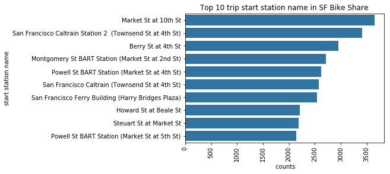

```python
#bar chart to display the relationship between start station name and the counts
base_color = sb.color_palette()[0]
start_station = fordgobike_clean.start_station_name.value_counts()[:10].index
sb.countplot(data = fordgobike_clean, y = 'start_station_name', color = base_color, order = start_station)
plt.xticks(rotation = 90)
plt.ylabel('start station name')
plt.xlabel(' counts')
plt.title('Top 10 trip start station name in SF Bike Share');
```

```python
fordgobike_clean.end_station_name.value_counts()[:10]
```

```
San Francisco Caltrain Station 2  (Townsend St at 4th St)    4624
Market St at 10th St                                         3709
Montgomery St BART Station (Market St at 2nd St)             3461
San Francisco Ferry Building (Harry Bridges Plaza)           3151
San Francisco Caltrain (Townsend St at 4th St)               2870
Powell St BART Station (Market St at 4th St)                 2854
Berry St at 4th St                                           2782
The Embarcadero at Sansome St                                2341
Steuart St at Market St                                      2264
Powell St BART Station (Market St at 5th St)                 2153
Name: end_station_name, dtype: int64
```

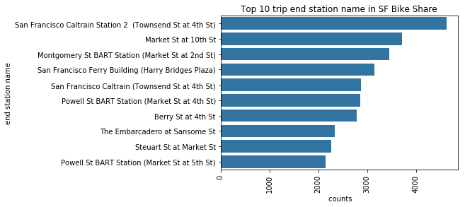

```python
#Bar chart to display the relationship between start station name and the counts
base_color = sb.color_palette()[0]
end_station = fordgobike_clean.end_station_name.value_counts()[:10].index
sb.countplot(data = fordgobike_clean, y = 'end_station_name', color = base_color, order = end_station)
plt.xticks(rotation = 90)
plt.ylabel('end station name')
plt.xlabel(' counts')
plt.title('Top 10 trip end station name in SF Bike Share');
```